# R Introduction

Li Zongzhang

2024-09-06

# 1 管道符

```r
安装和加载包tidyverse

install.packages("tidyverse")
library(tidyverse)

# %>% 快捷键
# Windows: Ctrl + Shift + M
# Mac OS : Cmd + Shift + M
```

```r
library(tidyverse)

x <- runif(10,0,1)
x
```

```
##  [1] 0.82892753 0.19616634 0.65931196 0.43699202 0.06658061 0.98358538
##  [7] 0.81278185 0.29431471 0.34387991 0.36754922
```

```r
round(sqrt(abs(log(x))),2)
```

```
##  [1] 0.43 1.28 0.65 0.91 1.65 0.13 0.46 1.11 1.03 1.00
```

```r
y <- log(x)
z <- abs(y)
w <- sqrt(z)
v <- round(w,2)
sort(v)
```

```
##  [1] 0.13 0.43 0.46 0.65 0.91 1.00 1.03 1.11 1.28 1.65
```

```r
x %>%
  log() %>%
  abs() %>%
  sqrt() %>%
  round(2) %>%
  sort()
```

```
##  [1] 0.13 0.43 0.46 0.65 0.91 1.00 1.03 1.11 1.28 1.65
```

```r
pi %>%
  round(2)
```

```
## [1] 3.14
```

```r
2 %>%
  round(pi,.)
```

```
## [1] 3.14
```

```r
6 %>%
  round(pi,.)
```

```
## [1] 3.141593
```

```r
6 %>%
  round()
```

```
## [1] 6
```

```r
#占位符
paste(1:3, letters[1:3])
```

```
## [1] "1 a" "2 b" "3 c"
```

```r
1:3 %>%
  paste(.,letters[.])
```

```
## [1] "1 a" "2 b" "3 c"
```

# 2 数据管理

- 筛选个案：filter()
- 选择变量：select()
- 追加变量：mutate()
- 重命名：rename(新名 = 旧名)
- 条件转换：二值转换if_else()
- 条件转换：多值转换case_when()

```r
data(mpg)

#1 miles per gallon = 0.425 kilometers per liter

mpg %>%
  filter(year == 1999) %>%
  select(displ,cty, hwy,trans) %>%
  arrange(displ) %>%
  mutate(cty.kpl = 0.425*cty,
               hwy.kpl = 0.425*hwy) %>%
  mutate(transmission =
           if_else(substring(trans, 1,4) == "auto",
                   "auto","manual"))
```

```
## # A tibble: 117 × 7
##    displ   cty   hwy trans      cty.kpl hwy.kpl transmission
##    <dbl> <int> <int> <chr>        <dbl>   <dbl> <chr>
##  1   1.6    28    33 manual(m5)   11.9     14.0 manual
##  2   1.6    24    32 auto(l4)     10.2     13.6 auto
##  3   1.6    25    32 manual(m5)   10.6     13.6 manual
##  4   1.6    23    29 manual(m5)    9.78    12.3 manual
##  5   1.6    24    32 auto(l4)     10.2     13.6 auto
##  6   1.8    18    29 auto(l5)      7.65    12.3 auto
##  7   1.8    21    29 manual(m5)    8.92    12.3 manual
##  8   1.8    18    26 manual(m5)    7.65    11.0 manual
##  9   1.8    16    25 auto(l5)      6.8     10.6 auto
## 10   1.8    24    30 auto(l3)     10.2     12.8 auto
## # ℹ 107 more rows
```

```r
mpgnew <- mpg %>%
  filter(year == 1999) %>%
  select(displ,cty, hwy,trans) %>%
  arrange(displ) %>%
  mutate(cty.kpl = 0.425*cty,
               hwy.kpl = 0.425*hwy) %>%
  mutate(transmission =
           if_else(substring(trans, 1,4) == "auto",
                   "auto","manual"))
```

```r
#二值转换 if_else

mpg$transmission <- if_else(
  substring(mpg$trans, 1,4) == "auto",
  "auto","manual")

#多值转换 case_when
mpg$drive <- case_when(
  mpg$drv == "f" ~ "front-wheel",
  mpg$drv == "r" ~ "rear-wheel",
  mpg$drv == "4" ~ "four-wheel")
```

# 3 散点图

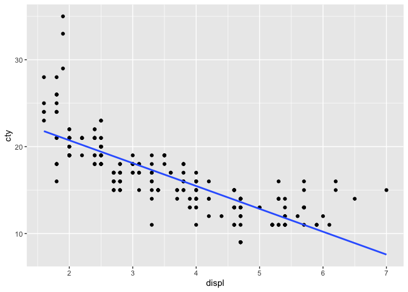

```r
data(mpg)

mpg %>%
  ggplot(aes(displ, cty))+
  geom_point()+
  geom_smooth(method = lm,
              se = F)
```

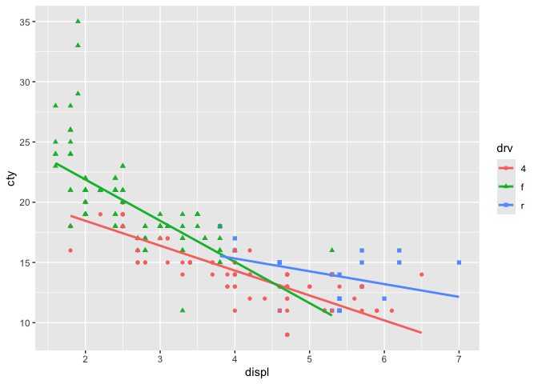

```r
mpg %>%
  ggplot(aes(displ, cty,
             color = drv,
             shape = drv))+
  geom_point()+
  geom_smooth(method = lm,
              se = F)
```

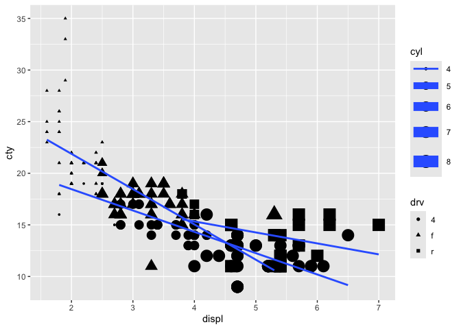

```r
mpg %>%
  ggplot(aes(displ, cty,
             size = cyl,
             shape = drv))+
  geom_point()+
  geom_smooth(method = lm,
              se = F)
```

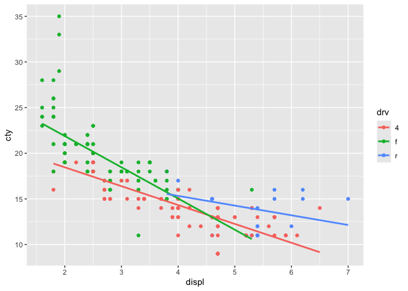

```r
mpg %>%
  ggplot(aes(displ, cty,
             color = drv))+
  geom_point()+
  geom_smooth(method = lm,
              se = F)
```

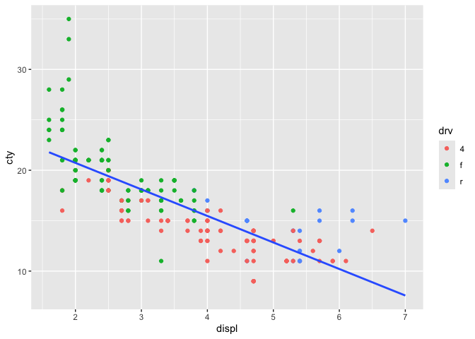

```r
mpg %>%
  ggplot(aes(displ, cty))+
  geom_point(aes(color = drv))+
  geom_smooth(method = lm,
              se = F)
```

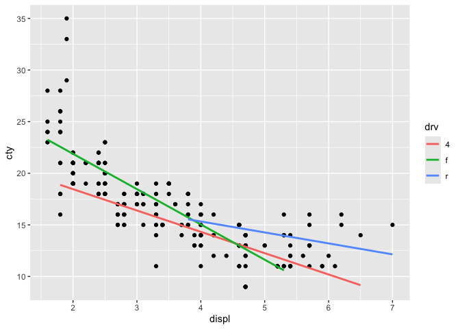

```r
mpg %>%
  ggplot(aes(displ, cty))+
  geom_point()+
  geom_smooth(aes(color = drv),
              method = lm,
              se = F)
```

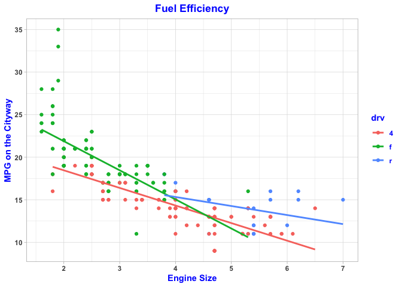

```r
mpg %>%
  ggplot(aes(displ, cty,
             color = drv))+
  geom_point()+
  geom_smooth(method = lm,
              se = F)+
  labs(x = "Engine Size",
       y = "MPG on the Cityway",
       title = "Fuel Efficiency")+
  theme_light()+
  theme(text = element_text(face = "bold",
                            colour = "blue"),
        plot.title = element_text(hjust = 0.5))
```

# 4 描述性统计量的报告

```r
summary(mpg)
```

```
##  manufacturer          model               displ            year
##  Length:234         Length:234         Min.   :1.600   Min.   :1999
##  Class :character   Class :character   1st Qu.:2.400   1st Qu.:1999
##  Mode  :character   Mode  :character   Median :3.300   Median :2004
##                                        Mean   :3.472   Mean   :2004
##                                        3rd Qu.:4.600   3rd Qu.:2008
##                                        Max.   :7.000   Max.   :2008
##       cyl           trans               drv                 cty
##  Min.   :4.000   Length:234         Length:234         Min.   : 9.00
##  1st Qu.:4.000   Class :character   Class :character   1st Qu.:14.00
##  Median :6.000   Mode  :character   Mode  :character   Median :17.00
##  Mean   :5.889                                         Mean   :16.86
##  3rd Qu.:8.000                                         3rd Qu.:19.00
##  Max.   :8.000                                         Max.   :35.00
##       hwy             fl               class
##  Min.   :12.00   Length:234         Length:234
##  1st Qu.:18.00   Class :character   Class :character
##  Median :24.00   Mode  :character   Mode  :character
##  Mean   :23.44
##  3rd Qu.:27.00
##  Max.   :44.00
```

```r
library(psych)
describe(mpg)
```

```
##               vars   n    mean    sd median trimmed   mad    min  max range
## manufacturer*    1 234    7.76  5.13    6.0    7.68  5.93    1.0   15  14.0
## model*           2 234   19.09 11.15   18.5   18.98 14.08    1.0   38  37.0
## displ            3 234    3.47  1.29    3.3    3.39  1.33    1.6    7   5.4
## year             4 234 2003.50  4.51 2003.5 2003.50  6.67 1999.0 2008   9.0
## cyl              5 234    5.89  1.61    6.0    5.86  2.97    4.0    8   4.0
## trans*           6 234    5.65  2.88    4.0    5.53  1.48    1.0   10   9.0
## drv*             7 234    1.67  0.66    2.0    1.59  1.48    1.0    3   2.0
## cty              8 234   16.86  4.26   17.0   16.61  4.45    9.0   35  26.0
## hwy              9 234   23.44  5.95   24.0   23.23  7.41   12.0   44  32.0
## fl*             10 234    4.63  0.70    5.0    4.77  0.00    1.0    5   4.0
## class*          11 234    4.59  1.99    5.0    4.64  2.97    1.0    7   6.0
##                skew kurtosis   se
## manufacturer*  0.21    -1.63 0.34
## model*         0.11    -1.23 0.73
## displ          0.44    -0.91 0.08
## year           0.00    -2.01 0.29
## cyl            0.11    -1.46 0.11
## trans*         0.29    -1.65 0.19
## drv*           0.48    -0.76 0.04
## cty            0.79     1.43 0.28
## hwy            0.36     0.14 0.39
## fl*           -2.25     5.76 0.05
## class*        -0.14    -1.52 0.13
```

绘制学术论文中的表1

```r
library(psych)
library(gt)
mpg %>%
  select_if(is.numeric) %>%
  describe() %>%
  select(n,mean,sd, median, min,max) %>%
  round(3) %>%
  format(nsmall =3) %>%
  cbind(variable = c("displ","year","cyl","cty","hwy"),.) %>%
  gt() %>%
  gtsave(filename = "table1.docx")
```

# 5 相关系数及其可视化

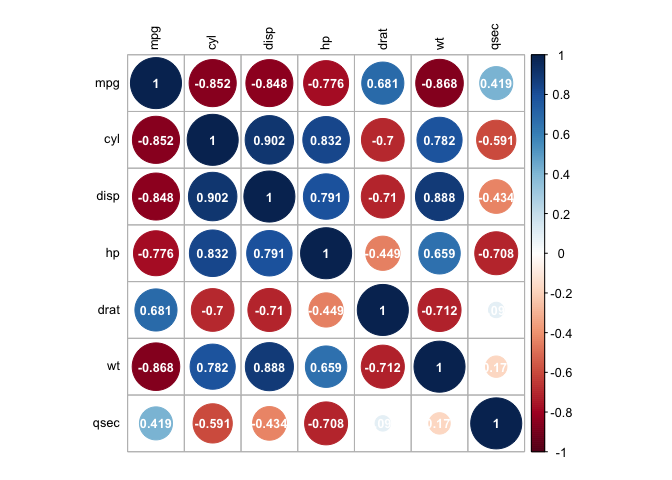

```r
library(tidyverse)
library(corrplot)
data(mtcars)

mtcars %>%
  select(mpg:qsec) %>%
  cor() %>%
  round(3) %>%
  corrplot(addCoef.col = "white",
           number.cex = 0.8,
           number.digits = 3,
           tl.cex = 0.8,
           tl.col = 1,
           cl.length = 11,
           mar = c(1,1,1,1))
```

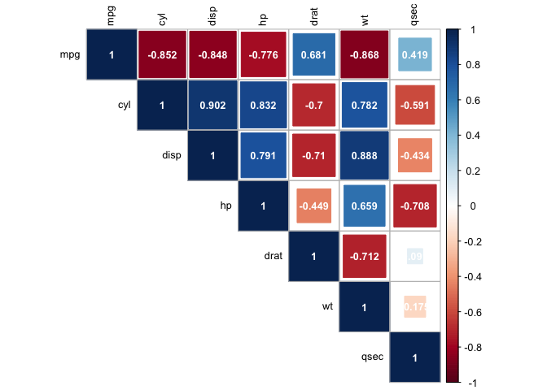

```r
mtcars %>%
  select(mpg:qsec) %>%
  cor() %>%
  round(3) %>%
  corrplot(addCoef.col = "white",
           number.cex = 0.8,
           number.digits = 3,
           tl.cex = 0.8,
           tl.col = 1,
           cl.length = 11,
           type = "upper",
           method = "square")
```

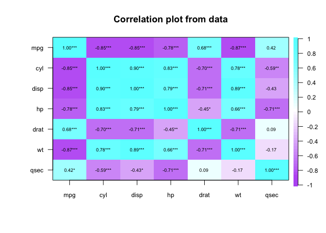

```r
library(psych)

gr <- colorRampPalette(c("#B52127", "white", "#2171B5"))

gr <- colorRampPalette(c("purple", "white", "cyan"))

mtcars %>%
  select(mpg:qsec) %>%
  cor.plot(cex = 0.6,
           stars = TRUE,
           gr = gr,
           cex.axis = 0.8)
```

# 6 习题1

数据集：mtcars

要求：

1.1 用select()函数从mtcars提取5个变量⽣成新的数据框。

1.2 用mutate()函数在数据框中追加新的变量，将油耗变量mpg（miles per gallon）转换成转公里/升(kilometers per liter)的油耗指标。

1.3 任选mpg中的某个变量，用if_else()函数对该变量的数值进⾏条件转换。

1.4 设置2个筛选条件，用filter()函数从mpg筛选个案⽣成新的数据框。

1.5 报告disp, hp, drat, wt, qsec的相关系数矩阵,并对相关系数矩阵进行可视化呈现。

1.6 任选两个定量变量，用ggplot绘制散点图,设置散点图的颜色、形状、大小，并添加一条回归线。

1.7 将32辆汽车按VS分成两组(Engine (0 = V-shaped, 1 = straight)),绘制分组散点图，用ggplot绘制散点图,设置散点图的颜色、形状、大小，并添加一条回归线。

提交要求：提交R script截图到91速课平台